# Quanteda Package Code-Through

Isabel Eusebio

10/11/2024

# Introduction

This code through explores the various uses of the *quanteda* package in R. After first learning about this package in Lab 4, I thought it would be interesting to further explore this package and how it can be utilized for text/sentiment analysis.

# Content Overview

# Quanteda Package

For this code through, the quanteda package is included, along with quanteda.textmodels, quanteda.textplots, and quanteda.textstats which all previously were part of the original quanteda package.

```r
library(quanteda)
library(quanteda.textmodels)
library(quanteda.textplots)
library(quanteda.textstats)
library(readtext)
```

```r
#load data
sotu10 <- readtext("https://raw.githubusercontent.com/datameister66/data/master/sou2010.txt")

sotu16 <- readtext("https://raw.githubusercontent.com/datameister66/data/master/sou2016.txt")
```

```r
#create corpus
corp1 <- corpus(sotu10)
corp2 <- corpus(sotu16)
sotu_corp <- corp1 + corp2
```

We can use the tokens() function from quanteda to clean up the data to be analyzed by removing various unnecessary characters.

```r
#setting the remove values to TRUE removes the assigned characters, setting the values to FALSE, leaves the characters
sotu_corp <- tokens( sotu_corp, remove_numbers = TRUE, remove_punct = FALSE, remove_separators = TRUE, remove_symbols = FALSE, )

stopwords <- c("i", "me", "my", "myself", "we", "our", "ours", "ourselves", "you", "your", "yours", "yourself", "yourselves", "he", "him", "his", "himself", "she", "her", "hers", "herself", "it", "its", "itself", "they", "them", "their", "theirs", "themselves", "what", "which", "who", "whom", "this", "that", "these", "those", "am", "is", "are", "was", "were", "be", "been", "being", "have", "has", "had", "having", "do", "does", "did", "doing", "a", "an", "the", "and", "but", "if", "or", "because", "as", "until", "while", "of", "at", "by", "for", "with", "about", "against", "between", "into", "through", "during", "before", "after", "above", "below", "to", "from", "up", "down", "in", "out", "on", "off", "over", "under", "again", "further", "then", "once", "here", "there", "when", "where", "why", "how", "all", "any", "both", "each", "few", "more", "most", "other", "some", "such", "no", "nor", "not", "only", "own", "same", "so", "than", "too", "very", "s", "t", "can", "will", "just", "don", "should", "now" )
#Removing stopwords
sotu_corp <-  tokens_remove(sotu_corp, stopwords)
```

## Analyzing the text

There are various functions within the quanteda package that allows individuals to analyze a text. Below are some examples.

### Utility Functions

There are various functions within the quanteda package that allow individuals to find the counts of objects.

```r
#ndoc counts the number of documents in a corpus
ndoc(sotu_corp)
```

```
## [1] 2
```

```r
#ntoken counts the number of tokens (total words)
ntoken(sotu_corp)
```

```
## sou2010.txt sou2016.txt
##        5238        3662
```

```r
#ntype counts the number of types (total unique words)
ntype(sotu_corp)
```

```
## sou2010.txt sou2016.txt
##        1671        1473
```

### index Function

The index() funtion locates a pattern within the text. The to/from columns express where in the text the pattern appears.

```r
index(sotu_corp, pattern = "secure*")
```

| docname | from | to | pattern |
| --- | --- | --- | --- |
| sou2010.txt | 4747 | 4747 | secure* |
| sou2016.txt | 421 | 421 | secure* |
| sou2016.txt | 3250 | 3250 | secure* |

### kwic Function

The kwic (keywords in context) function allows individuals to determine the context in which a word occurs.

```r
#example of finding a keyword in context
kwic(sotu_corp, pattern= "immigration")
```

| docname | from | to | pre | keyword | post | pattern |
| --- | --- | --- | --- | --- | --- | --- |
| sou2010.txt | 4744 | 4744 | ) continue work fixing broken | immigration | system - secure borders enforce | immigration |
| sou2016.txt | 142 | 142 | still needs . Fixing broken | immigration | system . Protecting kids gun | immigration |

```r
# adding the valuetype searches for (the default), regular expressions, or fixed expressions
kwic(sotu_corp, pattern = "right", valuetype = "regex") |>
    head()
```

| docname | from | to | pre | keyword | post | pattern |
| --- | --- | --- | --- | --- | --- | --- |
| sou2010.txt | 98 | 98 | crashed Black Tuesday , civil | rights | marchers beaten Bloody Sunday , | right |
| sou2010.txt | 253 | 253 | kids college . know anxieties | right | . They're new . struggles | right |
| sou2010.txt | 802 | 802 | , two million Americans working | right | would otherwise unemployed . ( | right |
| sou2010.txt | 867 | 867 | ( Applause . ) That's | right | - Recovery Act , also | right |
| sou2010.txt | 883 | 883 | Applause . ) Economists left | right | say bill helped save jobs | right |
| sou2010.txt | 1327 | 1327 | tax breaks companies create jobs | right | United States America . ( | right |

```r
#example of finding a key phrase in context
kwic(sotu_corp, pattern = phrase("United States")) |>
    head()
```

| docname | from | to | pre | keyword | post | pattern |
| --- | --- | --- | --- | --- | --- | --- |
| sou2010.txt | 1328 | 1329 | breaks companies create jobs right | United States | America . ( Applause . | United States |
| sou2010.txt | 1569 | 1570 | Well , accept second place | United States | America . ( Applause . | United States |
| sou2010.txt | 2297 | 2298 | choose career public service , | United States | America , one go broke | United States |
| sou2010.txt | 4360 | 4361 | launchers , ensuring deterrent , | United States | Russia completing negotiations farthest-reaching arms | United States |
| sou2010.txt | 5230 | 5231 | God bless . God bless | United States | America . ( Applause . | United States |
| sou2016.txt | 539 | 540 | economy , basic fact : | United States | America , right , strongest | United States |

# Visualizing the text

Quanteda has various additional packages that can be used alongside the original package in order to visualize the data. This includes quanteda.textplots, which is shown in example below of how wordclouds can be generated from the texts.

## Creating a dfm (document-feature matrix)

When performing statistical analysis, individuals must use the dfm() function to create a matrix that can be analyzed.

```r
dfm_sotu10 <- corp1 |>
 tokens(remove_punct = TRUE) |>
    tokens_remove(pattern = stopwords('english')) |>
    dfm() |>
    dfm_trim(min_termfreq = 10, verbose = FALSE)

dfm_sotu16 <- corp2|>
 tokens(remove_punct = TRUE) |>
    tokens_remove(pattern = stopwords('english')) |>
    dfm() |>
    dfm_trim(min_termfreq = 10, verbose = FALSE)

print(dfm_sotu10)
```

```
## Document-feature matrix of: 1 document, 59 features (0.00% sparse) and 0 docvars.
##              features
## docs          congress americans time give years america one nation people year
##   sou2010.txt       10        28   18   14    19      18  22     12     32   27
## [ reached max_nfeat ... 49 more features ]
```

```r
print(dfm_sotu16)
```

```
## Document-feature matrix of: 1 document, 36 features (0.00% sparse) and 0 docvars.
##              features
## docs          americans year   � ve make get back  s ll can
##   sou2016.txt        15   17 207 20   17  12   10 77 11  26
## [ reached max_nfeat ... 26 more features ]
```

## Creating a Word Cloud

You can use the frequency features to create a word cloud. You can also use a comparison cloud to compare word frequency of less than 8 documents.

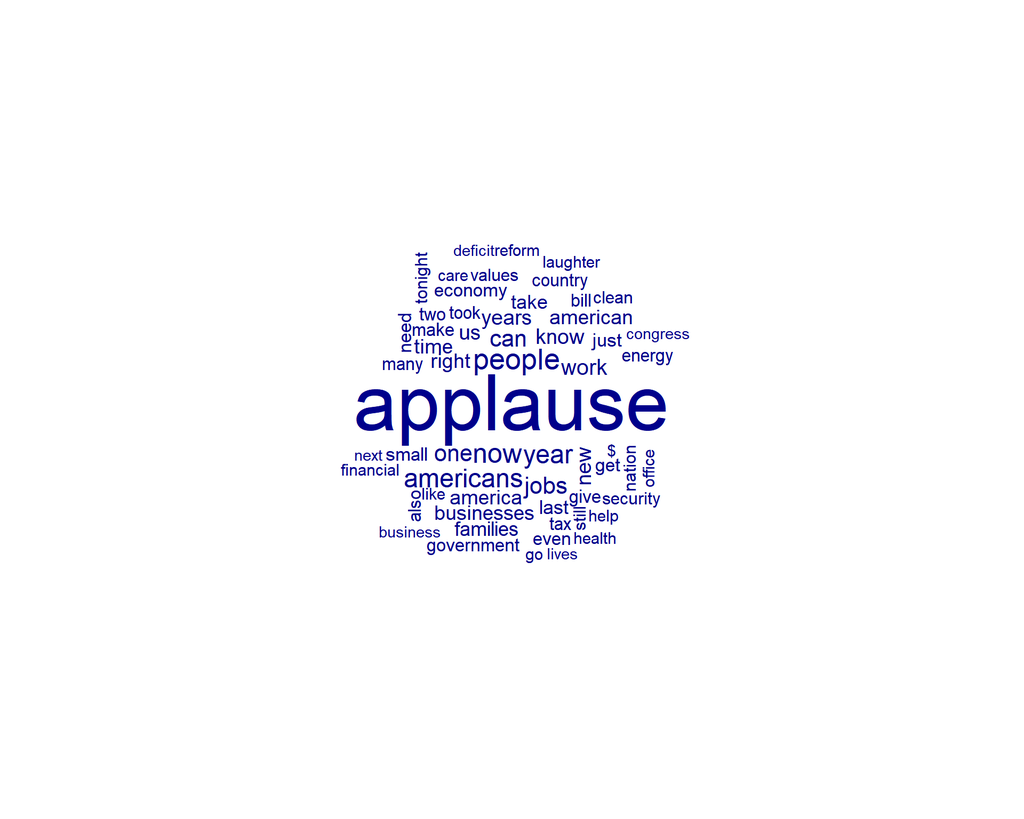

```r
#singular word cloud
set.seed(100)
textplot_wordcloud(dfm_sotu10)
```

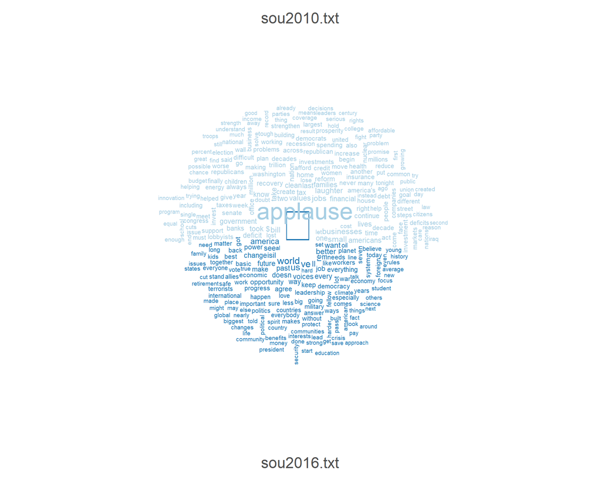

```r
#create dfm
dfm_sotu <- sotu_corp|>
 tokens(remove_punct = TRUE) |>
    tokens_remove(pattern = stopwords('english')) |>
    dfm() |>
    dfm_trim(min_termfreq = 5, verbose = FALSE)
#comparison cloud
  textplot_wordcloud(dfm_sotu, comparison = TRUE)
```

## Lexical Dispersion Plot

A lexical dispersion plot can take a kwic object and visualize the occurences of a word or phrase throughout a text. This creates a visual, similar to an x-ray, where individuals can see where within a text a certain word or phrase occurs.

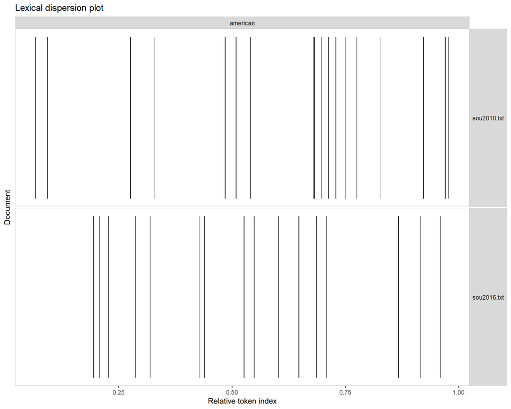

```r
kwic(sotu_corp, pattern = "american") |>
    textplot_xray()
```

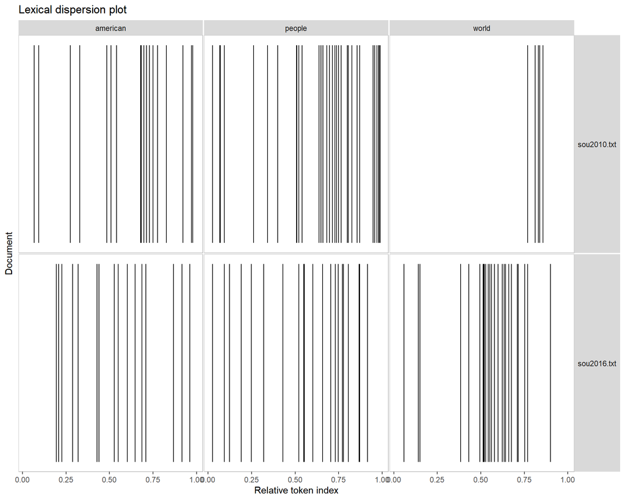

```r
textplot_xray(
     kwic(sotu_corp, pattern = "american"),
     kwic(sotu_corp, pattern = "people"),
     kwic(sotu_corp, pattern = "world")
)
```

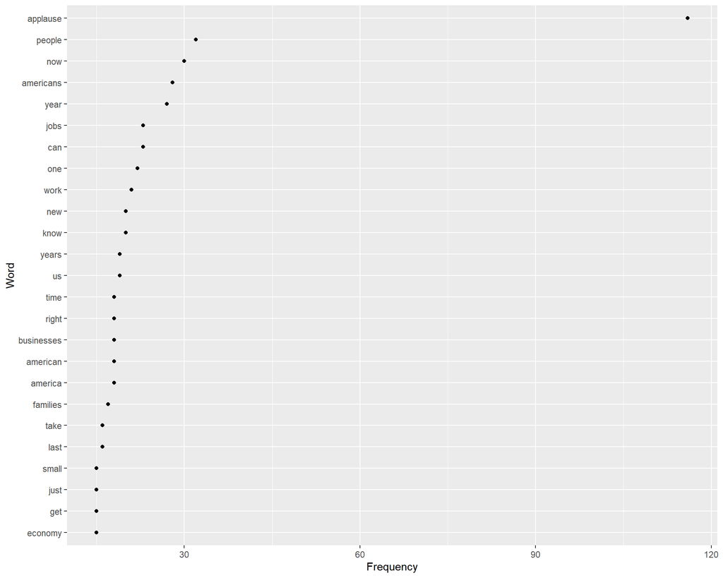

```r
library(ggplot2)
#find frequency of top 25 most used words
tstat_freq <- textstat_frequency(dfm_sotu10, n = 25)
#plot frequency
ggplot(tstat_freq, aes(x = frequency, y = reorder(feature, frequency)))+
    geom_point() +
    labs(x = "Frequency", y = "Word")
```

# Summary

The quanteda package set is an excellent resource that can be utilized in analyzing and visualizing textual data. It encompasses a set of functions that users can pre-process, tokenize, and analyze text corpa. It can be extremely helpful to researchers and analysts who work with large text datasets, who may be analyzing multiple documents or sources. It provides easy and scalable methods the extract meaningful insights from textual data.